# Aula 01

Prof. Dr. José Roberto Frega

03/03/2020

# 1 O R

O *prompt* do R pode ser usado como uma calculadora, simplesmente inserindo os números e operações

```r
2 + 2
```

```
[1] 4
```

```r
5/4
```

```
[1] 1.25
```

```r
18^2
```

```
[1] 324
```

```r
18^2-3*32+125/15
```

```
[1] 236.3333
```

Uma alternativa é usar uma variável para armazenar o resultado (observe que o R é sensível a maiúsculas e minúsculas)

```r
A = 18^2-3*32+125/15
a
```

```
Error in eval(expr, envir, enclos): objeto 'a' não encontrado
```

```r
A
```

```
[1] 236.3333
```

```r
Frega = 1
frega
```

```
Error in eval(expr, envir, enclos): objeto 'frega' não encontrado
```

```r
Frega
```

```
[1] 1
```

# 2 Um pouco de estatística

Tomemos os primeiros 10000 números naturais a partir do 1 (inteiros positivos)

```r
numeros = 1:10000
#
# Mostrarei somente os primeiros 10 e os últimos 10, por questão de espaço
#
head(numeros, 10)
```

```
 [1]  1  2  3  4  5  6  7  8  9 10
```

```r
tail(numeros, 10)
```

```
 [1]  9991  9992  9993  9994  9995  9996  9997  9998  9999 10000
```

## 2.1 Média

Para calcular a sua média, pode-se somá-los e dividir pelo número de elementos

$$\mu = \dfrac{\sum_{i=1}^N x_i}{N}$$

```r
sum(numeros)/10000
```

```
[1] 5000.5
```

Ou, simplesmente, usar a função *mean*

```r
mean(numeros)
```

```
[1] 5000.5
```

## 2.2 Desvio-padrão

O desvio-padrão populacional pode ser calculado como

$$\sigma = \sqrt{\dfrac{\sum_{i=1}^N \left(x_i-\mu\right)^2}{N}}$$

```r
sqrt(sum((numeros-mean(numeros))^2)/10000)
```

```
[1] 2886.751
```

Vamos guardar esses resultados para posterior comparação

```r
pop.media = mean(numeros)
pop.desvpad = sqrt(sum((numeros-mean(numeros))^2)/10000)
c(pop.media, pop.desvpad)
```

```
[1] 5000.500 2886.751
```

## 2.3 Amostragem

Para uma amostra, o cálculo dos estimadores é

$$\bar{x} = \dfrac{\sum_{i=1}^n x_i}{n}$$

$$s = \sqrt{\dfrac{\sum_{i=1}^n \left(x_i-\bar{x}\right)^2}{n-1}}$$

onde $n$ é o tamanho da amostra.

Dessa população de 10000 números, vamos tomar algumas amostras e calcular os seus estimadores (observe que usaremos a função *sd* que calcula o desvio-padrão amostral)

## 2.4 Estimadores amostrais

```r
# vou usar a função set.seed para inicializar o gerador de números aleatórios, assim teremos sempre as mesmas amostras, ou seja, os resultados serão replicáveis
#
set.seed(1)
#
amostra = sample(numeros, 30)
c(mean(amostra), sd(amostra))
```

```
[1] 5088.967 2949.068
```

```r
amostra = sample(numeros, 30)
c(mean(amostra), sd(amostra))
```

```
[1] 5139.800 2461.346
```

```r
amostra = sample(numeros, 30)
c(mean(amostra), sd(amostra))
```

```
[1] 5121.667 2693.307
```

Comparando com a população:

```r
c(pop.media, pop.desvpad)
```

```
[1] 5000.500 2886.751
```

Se tomarmos amostras maiores, os estimadores estarão mais próximos dos parâmetros populacionais:

```r
amostra = sample(numeros, 130)
c(mean(amostra), sd(amostra))
```

```
[1] 5185.977 2732.542
```

```r
amostra = sample(numeros, 130)
c(mean(amostra), sd(amostra))
```

```
[1] 4574.862 2826.165
```

```r
amostra = sample(numeros, 130)
c(mean(amostra), sd(amostra))
```

```
[1] 5026.115 2929.262
```

```r
c(pop.media, pop.desvpad)
```

```
[1] 5000.500 2886.751
```

```r
amostra = sample(numeros, 500)
c(mean(amostra), sd(amostra))
```

```
[1] 5043.060 2934.058
```

```r
amostra = sample(numeros, 500)
c(mean(amostra), sd(amostra))
```

```
[1] 4830.244 2929.510
```

```r
amostra = sample(numeros, 500)
c(mean(amostra), sd(amostra))
```

```
[1] 4991.074 3001.242
```

```r
c(pop.media, pop.desvpad)
```

```
[1] 5000.500 2886.751
```

# 3 Jogos

```r
#
# Este é um conjunto de funções que eu programei e que (ainda) não está disponível para vocês, ou seja,
# deste ponto em diante vocês não conseguirão executar o código
#
source("/Users/jfrega/Documents/R/LivroMQ1/jogo.R")
```

## 3.1 Criando um jogo

```r
j = clsJogo()
j$montaJogo(mm = c(1500, -800, 800, -400, 0, 0), coln = c("Fav", "Desf"))
j$m
```

```
    Fav Desf
A1 1500 -800
A2  800 -400
A3    0    0
```

## 3.2 Solução de Laplace

```r
lap = j$resolveLaplace()
lap[c(1, 3)]
```

```
$valores
      A1  A2 A3
[1,] 350 200  0

$solucao
 A1
350
```

## 3.3 Mínimo Arrependimento de Savage

```r
mr = j$resolveMinRegret()
mr
```

```
$maxcol
 Fav Desf
1500    0

$EVwPI
[1] 750

$opportunity.loss
    Fav Desf
A1    0  800
A2  700  400
A3 1500    0

$maxregret
  A1   A2   A3
 800  700 1500

$solucao
 A2
700
```

## 3.4 Valor esperado da informação perfeita

```r
j$EVPI()
```

```
$EVwPI
[1] 750

$Laplace
 A1
350

$EVPI
EVPI
 400
```

## 3.5 Sensibilidade

```r
sens = j$sensibilidade(graf = TRUE)
```

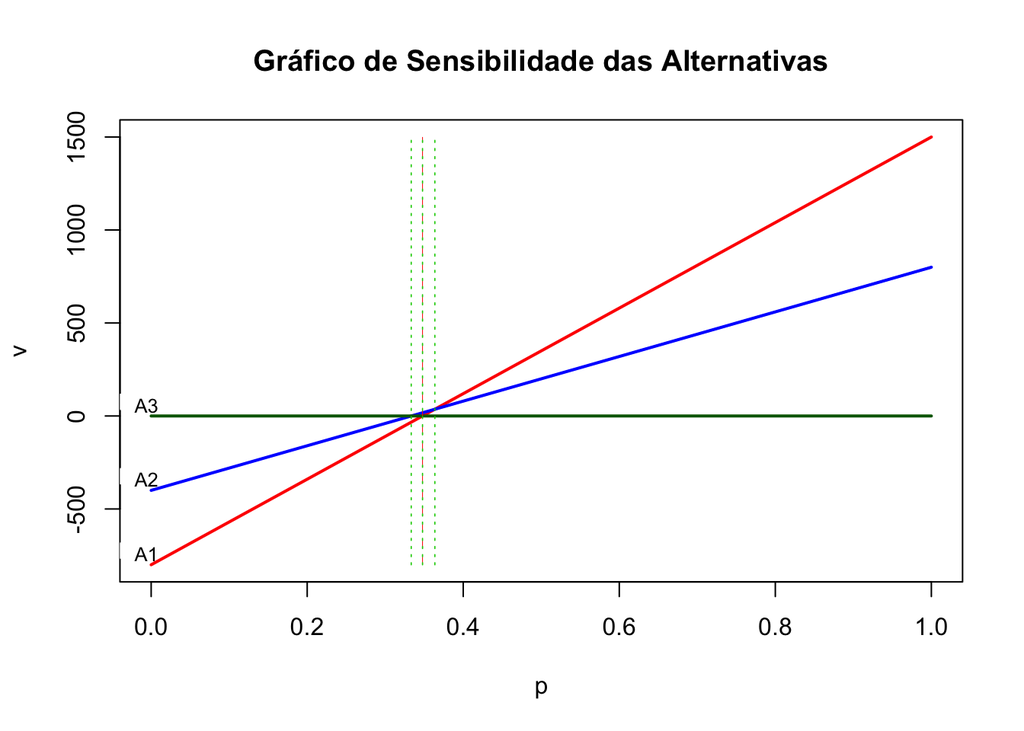

```r
sens
```

```
$eqs
         EMV3          EMV2          EMV1
     "0p + 0" "1200p - 400" "2300p - 800"

$p
  A3 - A2   A3 - A1   A2 - A1
0.3333333 0.3478261 0.3636364

$viaveis
  A3 - A2   A2 - A1
0.3333333 0.3636364
```

Nota-se que a alternativa A2 só é interessante no intervalo de probabilidade de 0.3333333 a 0.3636364.

## 3.6 Árvores de probabilidades

Um jogo pode ser representado por uma árvore. Por questões técnicas, eu recriei o mesmo jogo duplicando a alternativa A2, ou seja A2 e A3 são iguais em um jogo de 4 alternativas.

```r
j$montaJogo(c(1500, -800, 800, -400, 800, -400, 0, 0))
j$m
```

```
    Fav Desf
A1 1500 -800
A2  800 -400
A3  800 -400
A4    0    0
```

### 3.6.1 Árvore de Laplace

A solução de Laplace fica

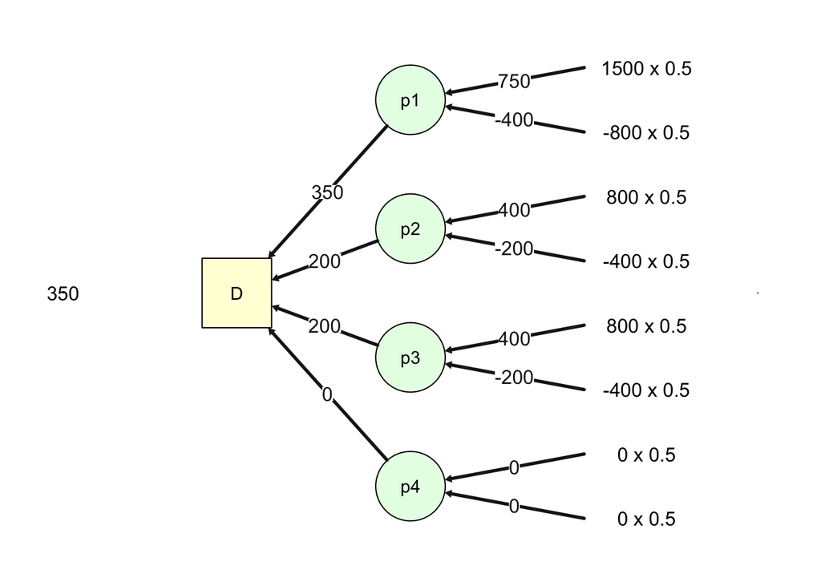

```r
j$plotSingleDecision(0.5)
```

### 3.6.2 Árvore completa com total desconhecimento

E a árvore completa para uma empresa de pesquisa que não sabe nada é

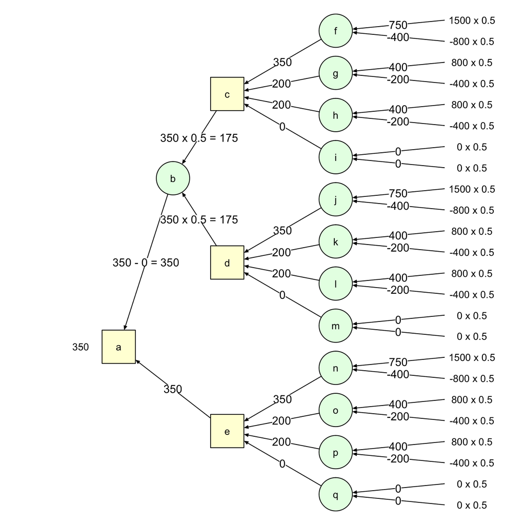

```r
j$plot(j$arvore(p = c(0.5, 0.5, 0.5), payoff = 0, posteriori = FALSE, dec = 2))
```

### 3.6.3 Árvore completa com desconhecimento parcial

Imaginando que a empresa de pesquisa acerta 80% dos casos de mundo favorável e acerta 70% dos casos de mundo desfavorável, a árvore fica

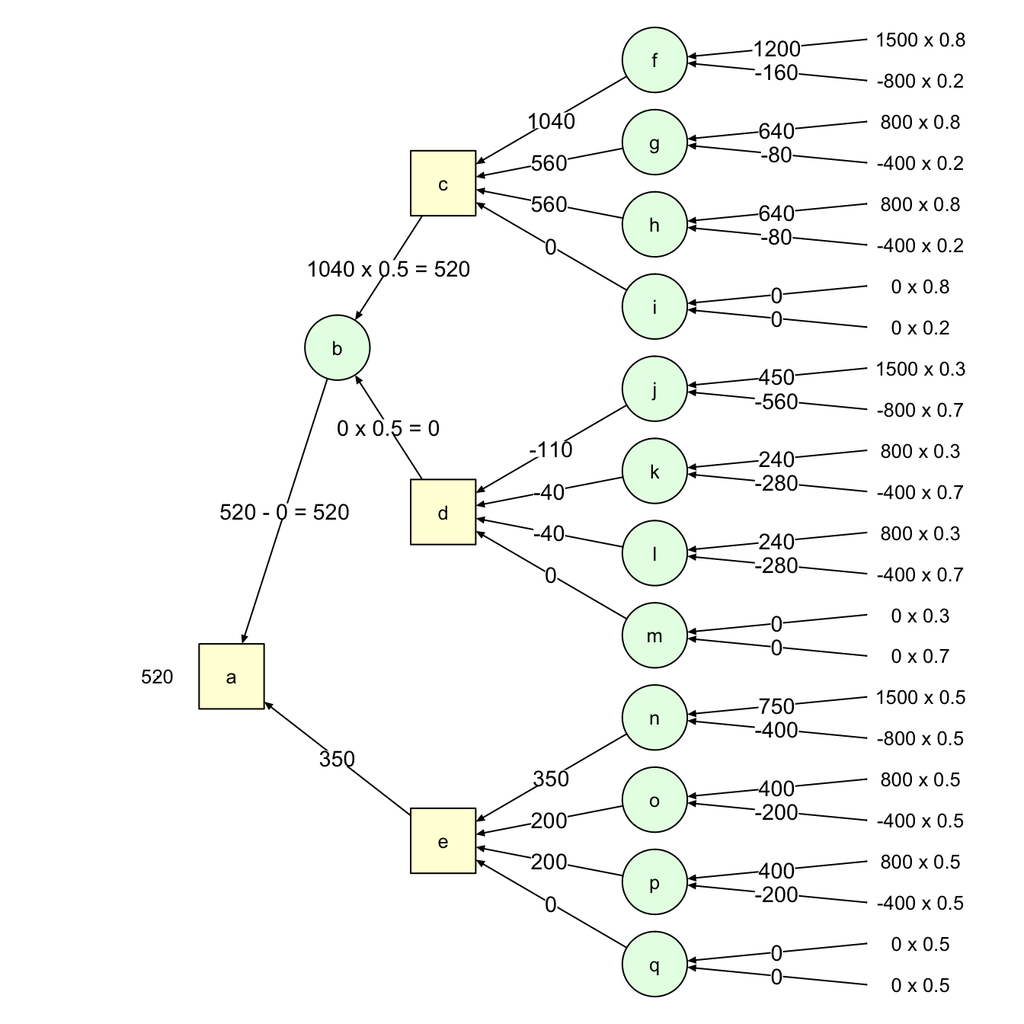

```r
j$plot((arv1 = j$arvore(p = c(0.5, 0.8, 0.3), payoff = 0, posteriori = FALSE, dec = 2)))
```

```r
print(arv1[-8], na.print = "")
```

```
$p
      [,1] [,2]
ppesq  0.5  0.5
pfav   0.8  0.2
pdesf  0.3  0.7

$jogo
    Fav Desf
A1 1500 -800
A2  800 -400
A3  800 -400
A4    0    0

$pesq.fav
        Valor Prob Resultado  EMV Maior EMV
A1 Fav   1500  0.8      1200 1040      1040
A1 Desf  -800  0.2      -160
A2 Fav    800  0.8       640  560
A2 Desf  -400  0.2       -80
A3 Fav    800  0.8       640  560
A3 Desf  -400  0.2       -80
A4 Fav      0  0.8         0    0
A4 Desf     0  0.2         0

$pesq.desfav
        Valor Prob Resultado  EMV Maior EMV
A1 Fav   1500  0.3       450 -110         0
A1 Desf  -800  0.7      -560
A2 Fav    800  0.3       240  -40
A2 Desf  -400  0.7      -280
A3 Fav    800  0.3       240  -40
A3 Desf  -400  0.7      -280
A4 Fav      0  0.3         0    0
A4 Desf     0  0.7         0

$pesquisa
          Valor Prob Resultado EMV Payoff Valor Pesquisa
Pesq Fav   1040  0.5       520 520      0            520
Pesq Desf     0  0.5         0

$laplace
[1] 350

$resultado
[1] "Fazer pesquisa é preferível à solução de Laplace"

$vrpesquisa
[1] 520
```

### 3.6.4 Árvore completa com desconhecimento parcial e probabilidades *a posteriori*

E, fazendo as contas do Reverendo Bayes, tem-se

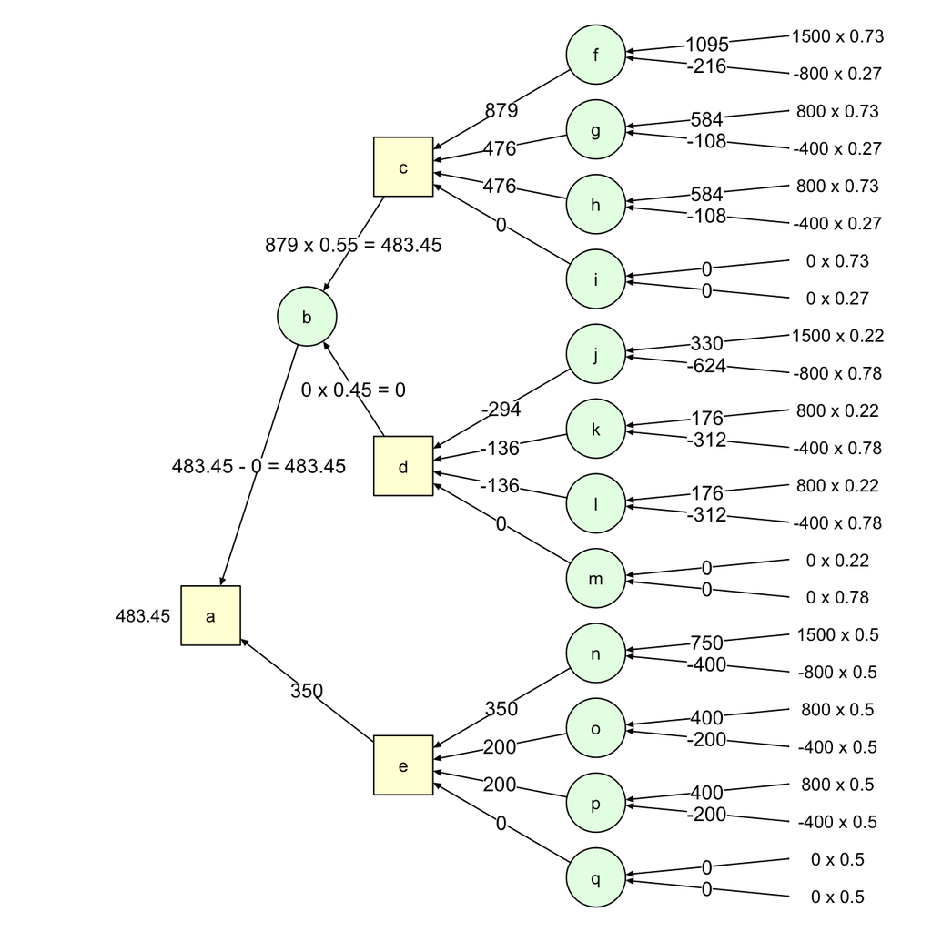

```r
j$plot((arv2 = j$arvore(p = c(0.5, 0.8, 0.3), payoff = 0, posteriori = TRUE, dec = 2)))
```

```r
print(arv2[-8], na.print = "")
```

```
$p
      Escolha Escolha
ppesq    0.55    0.45
pfav     0.73    0.27
pdesf    0.22    0.78

$jogo
    Fav Desf
A1 1500 -800
A2  800 -400
A3  800 -400
A4    0    0

$pesq.fav
        Valor Prob Resultado EMV Maior EMV
A1 Fav   1500 0.73      1095 879       879
A1 Desf  -800 0.27      -216
A2 Fav    800 0.73       584 476
A2 Desf  -400 0.27      -108
A3 Fav    800 0.73       584 476
A3 Desf  -400 0.27      -108
A4 Fav      0 0.73         0   0
A4 Desf     0 0.27         0

$pesq.desfav
        Valor Prob Resultado  EMV Maior EMV
A1 Fav   1500 0.22       330 -294         0
A1 Desf  -800 0.78      -624
A2 Fav    800 0.22       176 -136
A2 Desf  -400 0.78      -312
A3 Fav    800 0.22       176 -136
A3 Desf  -400 0.78      -312
A4 Fav      0 0.22         0    0
A4 Desf     0 0.78         0

$pesquisa
          Valor Prob Resultado    EMV Payoff Valor Pesquisa
Pesq Fav    879 0.55    483.45 483.45      0         483.45
Pesq Desf     0 0.45      0.00

$laplace
[1] 350

$resultado
[1] "Fazer pesquisa é preferível à solução de Laplace"

$vrpesquisa
[1] 483.45
```